# Part II - (effects of bike riders on trip duration)

## by (Youssef Al-lehyani)

## Investigation Overview

In this investigation, I wanted to look at the data of the members characteristics and how this affects the duration of the trip. The main focus was on the five things duration_sec,member_gender,member_birth_year,user_type and bike_share_for_all_trip.

## Dataset Overview

This data set includes information about individual rides made in a bike-sharing system covering the greater San Francisco Bay area. it has regarding (18,3412), including duration_sec, member_gender, and other trip information..

## Distribution of Duration seconds

Duration seconds has a long-tailed distribution, with a lot of members finishing the race in record time and some of them needing a long time to finish the race, when we plotted on a log scale, the Duration looked like an as normal distribution

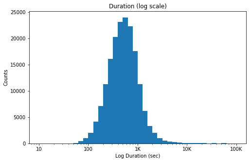

## The gender of members

Almost male make up three quarters of the members with a percentage of about (74.6%) while women make up about (23.3%) while the rest are about (2.1%)

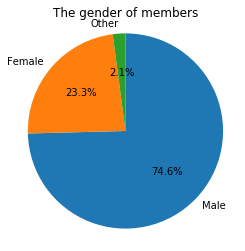

## duration seconds vs member birth year

we have more then 8000 members fished the trip in the 500 seconds and they were born between 1980 and 2000.also, there were some members were needing more than 1000 seconds to finish the trip but The strange thing was they were born between 1980 and 2000 too.

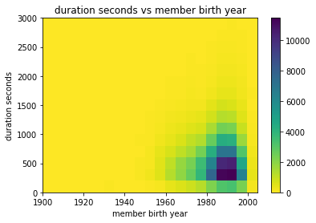

## duration seconds vs member birth year for (every gender)

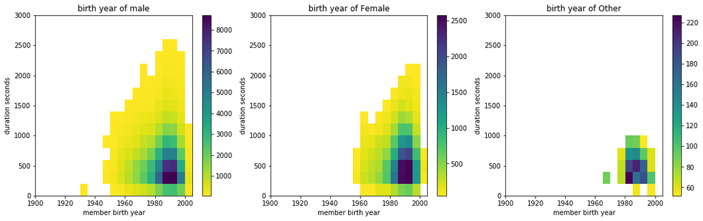

## duration seconds vs User type (Filter by gender)

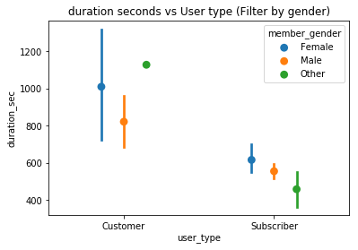